# **Regresión Lineal Múltiple**

*Este material es parte de la* *Unidad 3 del Curso de Epidemiología - Nivel Avanzado del Instituto Nacional de Epidemiología “Dr. Juan H. Jara” - ANLIS*

[Regresión Lineal Múltiple](https://cballejo.github.io/R_Epi_Avanzada/Unidad3/RLM/) by [Andrea Silva y Christian Ballejo](http://www.ine.gov.ar) is licensed under CC BY-NC 4.0

[figure not shown]

## Introducción

Los modelos de Regresión Lineal Múltiple (RLM) son típicamente empleados cuando la variable respuesta (o dependiente) es continua. Las variables independientes (variables explicativas o co variables) pueden ser tanto continuas como categóricas. A su vez las variables categóricas pueden ser dicotómicas, ordinales o tener múltiples niveles, siendo tratadas, en esta situación, como variables *dummy* (según veremos más adelante).

Así como la RLS nos permite estimar el efecto bruto de una variable independiente sobre una variable respuesta, la RLM nos permite conocer el efecto conjunto de 2 o más variables independientes ($X_1$, $X_2$,…$X_k$) sobre la variable respuesta ($Y$). De esta manera podemos decir que la RLM nos permite:

- Analizar la dirección y fuerza de la asociación entre la variable dependiente y las variables independientes.
- Determinar cuáles variables independientes son importantes en la **PREDICCIÓN / EXPLICACIÓN** de la variable dependiente
- Describir la relación entre una o más variables independientes controlando por el efecto de las otras variables independientes $\rightarrow$ evaluamos **CONFUSIÓN**
- Identificar si la relación de la variable respuesta y una variable independiente cambia de acuerdo al nivel de otra variable independiente $\rightarrow$ evaluamos **INTERACCION**

El modelo estadístico de la RLS que expresa la relación entre $X$ e $Y$ es:

$$Y = \beta_0 + \beta_1X_1$$

La representación gráfica de dicha relación es una recta de ajuste que se realiza en un plano (2 dimensiones).

El modelo estadístico de la RLM es:

$$Y = \beta_0 + \beta_1X_1 + \beta_2X_2 + ...+\beta_kX_k$$

Donde $\beta_0$, $\beta_1$, $\beta_2$,…,$\beta_k$ son los parámetros de la regresión. Para cada combinación de valores de $X_1$, $X_2$,…$X_k$ existe una distribución $Y$ cuya **media** es una función lineal de $X_1$, $X_2$,…, $X_k$.

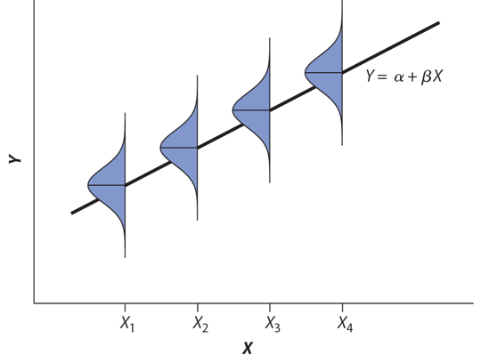

La representación gráfica de la recta de ajuste se realiza en el espacio de dimensión $K + 1$ ($K$ es el número de variables). Recordamos que en el caso de la RLS, podíamos representarla en un plano (2 dimensiones), en el caso de la RLM, se nos dificulta la representación espacial si el modelo tuviera más de 2 variables.

En el caso puntual que el modelo tuviera 2 variables independientes, la ecuación sería: $Y = \beta_0 + \beta_1X_1 + \beta_2X_2$

Y podríamos representarlo:

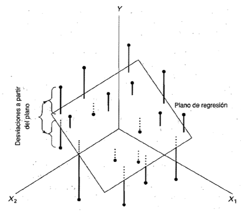

En forma similar a la RLS, la interpretación de cada parámetro$\beta$ de la regresión es:

- $\beta_0$: es el valor esperado de $Y$ cuando todas las otras variables son iguales a cero.
- $\beta_1$ es la pendiente a lo largo del eje $X_1$ y representa el cambio esperado en la respuesta por unidad de cambio en $X_1$ a valores constantes de $X_2$.
- $\beta_2$ es la pendiente a lo largo del eje $X_2$ y representa el cambio esperado en la respuesta por unidad de cambio en $X_2$ a valores constantes de $X_1$.

### Presupuestos del modelo de RLM

**1. Independencia**: las observaciones $Y_i$ son independientes unas de otras: el efecto de $X_1$ sobre la respuesta media no depende de $X_2$ y viceversa, siempre y cuando no exista interacción. Cuando existe interacción entre $X_1$ e $X_2$ , el efecto de $X_1$ sobre la respuesta media de $Y$ depende $X_2$ y viceversa ($X_1$ e $X_2$ no son independientes cuando existe interacción).

**2. Linealidad**: para cada combinación de valores de las variables independientes ($X_1$, $X_2$,…, $X_k$) el valor medio de $Y$ es función lineal de $X_1$, $X_2$,…,$X_k$.. La linealidad se define en relación a los coeficientes de la regresión, por lo tanto el modelo puede incluir términos cuadráticos e interacciones

$Y = \beta_0 + \beta_1X_1 + \beta_2X_2 + \beta_3X_1X_2\rightarrow$ modelo con interacción

$Y = \beta_0 + \beta_1X_1 + \beta_2X_2 + \beta_3X_1^2 + \beta_4X_2^2\rightarrow$ modelo con términos cuadráticos

**3. Homocedasticidad**: la varianza de $Y$ para los distintos valores de $X_1$, $X_2$,…,$X_k$ se mantiene constante

**4. Normalidad**: Los valores de $Y$ tienen una distribución normal según los valores de $X_1$, $X_2$, $X_k\rightarrow$ ésto nos permite realizar inferencias en relación a los parámetros del modelo.

Al igual que en la RLS la estimación de los parámetros de la regresión (coeficientes) se realiza mediante el **Método de los Mínimos Cuadrados** (MMC).

El MMC consiste en adoptar como estimativas de los parámetros de la regresión los valores que minimicen la suma de los cuadrados de los residuos

$$\sum_{i=1}^{i=n}e_1^2=\sum_{i=1}^{i=n}(Y_i-\hat{Y_i})^2=\sum_{i=n}^{i=n}(Y_i-(\hat{\beta}_0+\hat{\beta}_1X_1+\dots+\hat{\beta}_kX_k))^2$$

Comenzaremos aprendiendo a interpretar un modelo de RLM, para luego aprender a construirlos. Para ello, observemos detalladamente el resultado de un modelo de RLM en R, donde modelamos la V23, en función de las variables V10, V11, V12, V14, V15, V17, V18 y V24.

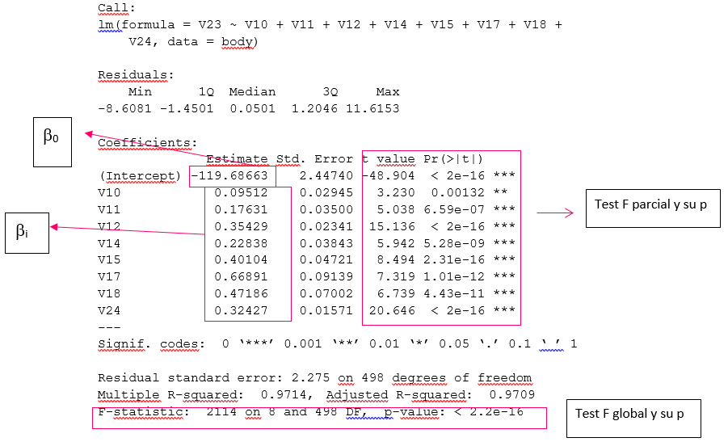

La primera columna muestra los coeficientes estimados por el modelo de RLM, la segunda el error estándar de cada coeficiente, las siguientes columnas muestran el estadístico $F$ parcial y su $p$ valor.

En el párrafo final encontramos: el error estándar de los residuos, el $R_2$ múltiple y el ajustado, y el estadístico de un test $F$ global con su $p$ valor. Profundicemos ahora en lo que significa cada uno de estos puntos.

**Test F parcial**

Como estamos sacando conclusiones partiendo de una muestra, es obvio que distintas muestras van a dar distintos valores de los parámetros. Es por eso que el test $F$ parcial, testea la siguiente afirmación o hipótesis:

$H_0=\beta_1=\beta_2=\dots\beta_n=0$

$H_1=\exists\beta_i\neq0$ (existe al menos un coeficiente $\neq$ 0)

De alguna forma, evalúa la contribución de cada variable al modelo. Nos dice si la inclusión de esa variable es útil para explicar significativamente la variabilidad observada en $Y$. En los modelos lineales generalizados (MLG), el *test de Wald* testea esta $H_0$. Para RLM, el test $F$ parcial es idéntico a Wald.

**Varianza residual**

Como vimos en ANOVA y al igual que en el caso de regresión lineal simple, vamos a descomponer la variabilidad de la variable dependiente Y en dos componentes o fuentes de variabilidad: un componente va a representar la variabilidad explicada por el modelo de regresión y el otro componente va a representar la variabilidad no explicada por el modelo y, por tanto, atribuida a factores aleatorios.

Variabilidad total = Variabilidad Regresión + Variabilidad residual

Suma de cuadrados totales (SCT) = Suma de cuadrados de la regresión (SCR) + Suma de cuadrados Residuales (SCE)

$$\sum (y_i-\bar{y})^2 = \sum (\hat{y}-\bar{y})^2 + \sum (y_i -\hat{y}_i)^2$$

$$\frac{Suma \; de \; cuadrados}{totales \; (SCT)} \; \frac{Suma \; de \; cuadrados}{de \; la \; regresion \; (SCR)} \; \frac{Suma \; de \; cuadrados}{residuales \; (SCE)}$$
Recordemos que cada uno de estos términos, se divide por sus grados de libertad para obtener los cuadrados medios correspondientes (CMT/CMR/CME)

|  | Grados de libertad | CM |
| --- | --- | --- |
| SCT | n-1 | CMT=SCT/n-1 |
| SCR | k-1 | CMR=SCR/k-1 |
| SCE | n-k-1 | CME= SCE/n-k-1 |

**Test F global**

Compara el modelo de regresión con el modelo nulo. Evalúa el efecto conjunto de las variables independientes incluidas en el modelo ajustado.

$F = CMR/CME \; \; \; \;gl= (k-1, n-k-1)$

### Coeficiente de determinación

Al igual de lo que aprendimos en la RLS la bondad de ajuste del modelo de RLM se valora con el coeficiente de determinación ($R^2$), que nos dice qué proporción de la variabilidad de $Y$ es explicada por los coeficientes de la regresión del modelo en estudio. El $R^2$ es útil para comparar entre modelos

$$R^2 = \frac{SCT-SCE}{SCT}=\frac{SCR}{SCT}$$
Sin embargo, en el caso de la RLM, en donde deseamos incluir en el modelo más de una variable independiente, el $R^2$ siempre va a mejorar al agregar una nueva variable, aunque su inclusión no mejore sustancialmente el modelo. El $R^2$ más grande se obtiene por el simple hecho de incluir todas las variables disponibles, pero la mejor ecuación de regresión múltiple no necesariamente utiliza todas las variables. El $R^2$ ajustado o corregido tiene esta expresión:

$$R^2_a = 1 - \bigg [ \frac{n-1}{n-(k+1)}\bigg]\frac{SCE}{SCT}=1-\bigg[\frac{n-1}{n-(k+1)}\bigg](1-R^2)$$

Teniendo en cuenta que 1-$R^2$ es un número constante y que $n$ es mayor que $k$, a medida que añadimos variables al modelo, el cociente entre paréntesis se hace más grande. Consecuentemente, también el resultado de multiplicar este por 1-$R^2$. Con lo cual vemos que la fórmula está construida para ajustar y penalizar la inclusión de coeficientes en el modelo.

Cuando tenemos que elegir el mejor modelo será necesario utilizar distintos criterios para compararlos y basar nuestra decisión en elegir el modelo que mejor explique la variación de $Y$ con el menor número de variables independientes, el modelo más simple y efectivo $\rightarrow$ también llamado el modelo más parsimonioso.

Antes de aprender a construir modelos de regresión, es necesario que repasemos algunos conceptos: comenzamos con variables confusoras y variables modificadoras de efecto.

**Confusión**. Una variable de confusión es una variable que distorsiona la medida de la asociación entre otras dos variables. El resultado en presencia de una variable de confusión puede ser la observación de:

1. Efecto donde en realidad no existe (Asociación espuria)
2. Exageración o atenuación de una asociación real (confusión positiva)
3. Inversión del sentido de una asociación real (confusión negativa).

Según Gordis, en un estudio sobre si la exposición A es una causa de la enfermedad B, se dice que un tercer factor, el factor X, es un factor de confusión si se cumple lo siguiente:

1. El factor X es un factor de riesgo conocido para la enfermedad B.
2. El factor X se asocia con la exposición A, pero no es un resultado de la exposición A.

Para quienes necesitan repasar este tema, pueden leer:

http://halweb.uc3m.es/esp/Personal/personas/amalonso/esp/bstat-tema8vc.pdf

Dentro de las estrategias para manejar la confusión, podemos pensar en dos momentos:

- A la hora de diseñar y llevar a cabo el estudio:
1. Emparejamiento individual.
2. Emparejamiento de grupo.
- Al momento de analizar los datos:
1. Estratificación.
2. Ajuste.

El ajuste estadístico es la propiedad de los análisis multivariados por la que se determina la influencia específica de cada variable independiente sobre la variable dependiente al mantener el resto de variables constantes. Aprenderemos a continuación a identificar variables confusoras en los modelos de RLM. En términos generales, se habla de confusión cuando existen diferencias importantes entre las estimaciones brutas de una asociación y las ajustadas por los posibles factores de confusión. En general existe un consenso en la bibliografía: un factor puede considerarse de confusión cuando su ajuste es responsable de un cambio de al menos un 10% en la magnitud de la diferencia entre las estimaciones ajustadas y las brutas.

**Interacción o modificación de efecto**. MacMahon definió la interacción de la siguiente manera: *“Cuando la incidencia de la enfermedad en presencia de dos o más factores de riesgo difiere de la incidencia que sería previsible por sus efectos individuales”*. El efecto puede ser mayor de lo esperado (interacción positiva, sinergismo) o menor de lo esperado (interacción negativa, antagonismo).El problema consiste en determinar qué sería lo esperado en los efectos individuales de las exposiciones.

Para quienes necesiten repasar el tema, pueden leer:

http://www.est.uc3m.es/amalonso/esp/bstat-tema8vme.pdf

Es importante destacar que mediante la RLM es posible identificar la presencia de modificadores de efecto mediante la inclusión de términos de interacción.

Seguramente recordarán de cursos previos de epidemiología, que frente a un modificador de efecto (ME) lo más adecuado era presentar las medidas de asociación según los estratos formados por las categorías de la variable ME (no estimar una medida ajustada para ambos estratos, como se hace en caso de variables confusoras). Al ajustar un modelo de RLM podemos incluir un término de interacción en la ecuación (que es el producto de ambas variables), el cual representa una nueva variable. El término de interacción implica el exceso de la variabilidad de los datos que no puede ser explicada por la suma de las variables consideradas.

A continuación se muestra un modelo que incluye interacción entre $X_1$ y $X_2$.

$$Y = \beta_0 + \beta_1X_1+\beta_2X_2+\beta_3X_1X_2$$

### Variables dummy

Recordemos que en el modelo de regresión podemos incluir como variables independientes tanto variables cuantitativas como variables categóricas. Las variables categóricas pueden ser dicotómicas (sexo: fem/masc; hábito de fumar: si/no) o tener más de dos categorías, por ejemplo: grupo sanguíneo, religión, color de ojos.

Para ser modeladas: cada categoría se transforma en una variable dicotómica ($n$ de categorías -1) donde 1 = tener esa característica. Se utiliza como grupo basal (no expuestos) a la categoría de menor valor. Cuando las variables cualitativas no ordinales sufren esta transformación se denominan variables *dummy*.

Veamos un ejemplo con una variable cualitativa dicotómica Hábito de Fumar (1:si 0:no):

Al ajustar un modelo con la variable Hábito de Fumar (1:si 0:no) el modelo quedaría:

$$Y = b_0+b_1F_1$$
$b_1$ es la variación que experimentará $Y$ en caso de que el individuo fume.

Veamos un ejemplo con la variable *“región”* con 3 categorías: NE-Norte (N)-Centro Oeste (CO).

Para modelarlas la transformaremos en 2 categorías: $Re_1$ y $Re_2$ ($n$ categorías -1)

| Región | Re1 | Re2 |
| --- | --- | --- |
| NE (basal) | 0 | 0 |
| N | 1 | 0 |
| CO | 0 | 1 |

$Re_1$=1 si vive en el norte

$Re_1$=0 si vive en otra región

$Re_2$=1 si vive en el CO

$Re_2$=0 si vive en otra región

Ahora imaginemos el modelo de regresión entre $Y$ y la variable *“región”* (supongamos que $Y$ es la Tasa de Mortalidad Infantil)

$$Y = b_0+b_1Re_1 + b_2Re_2$$
Para interpretar el modelo, cuando consideremos la región norte ($Re_1$=1 y $Re_2$=0) la ecuación será:

$$Y=b_0+b_1Re_1$$
Cuando consideremos la región CO ($Re_1$=0 y $Re_2$=1) la ecuación será:

$$Y=b_0+b_2Re_2$$

Cuando consideremos la región NE ($Re_1$=0 y $Re_2$=0) la ecuación será:

$$Y=b_0$$

El coeficiente $b_1$ y $b_2$ nos estarán indicando cuánto se modifica la TMI según consideremos la región N o CO. El coeficiente $b_0$ es el valor basal medio de la TMI considerada en la región NE.

Las variables dummy (también llamadas variables indicadoras) no tienen ningún sentido por sí solas y, por lo tanto, deben figurar todas las categorías en los modelos y se debe contrastar su inclusión siempre en bloque, aunque el test F parcial para alguna categoría resulte no significativo.

### Estimación y predicción

Los modelos de regresión se pueden utilizar esencialmente:

1. Con fines explicativos: obtener estimativas precisas sobre variables de interés para realizar inferencias o cuantificar relaciones entre variables controlando por otras variables)
2. Con fines predictivos: a partir de los datos de una muestra predecir el comportamiento de $Y$ según posibles valores de $X_k$.

Es importante tener en cuenta que si el propósito es construir un modelo predictivo a partir de una ecuación de regresión debe tener en cuenta:

1. Si no existe una correlación lineal, no utilice la ecuación de regresión para hacer predicciones. En ese caso el mejor predictor de los datos será su media muestral. Sólo haga predicciones si la ecuación de regresión es un buen modelo para los datos.
2. No haga predicciones en base a valores que rebasen las fronteras de los datos muestrales conocidos.
3. Debe estar basada en datos actualizados
4. No haga predicciones acerca de una población distinta de la población de donde se obtuvieron los datos muestrales.
5. La relación entre la variable respuesta y la predictora no debe ser necesariamente causal. En cambio cuando el objetivo del modelo es explicativo la relación causal (particularmente la relación temporal entre la variable dependiente y la independiente) debe existir.

### Lineamientos para el uso de la ecuación de regresión

Dada una variable dependiente $Y$ y un conjunto de $k$ variables independientes $X_1$, $X_2$, $X_3$….,$X_k$ ¿cuál es el mejor conjunto de $p$ predictores ($p \leq k$) y el correspondiente modelo de regresión para describir la relación entre $Y$ y las variables $X$?

Pasos para escoger la mejor ecuación de regresión:

1. Especificar el conjunto de variables potencialmente predictivas/explicativas y la forma del modelo.
2. Especificar un criterio estadístico para la elección de las variables.
3. Especificar una estrategia para seleccionar variables.
4. Conducir el análisis específico.
5. Evaluar los presupuestos del modelo
6. Evaluar la confiabilidad del modelo escogido.

**Paso 1**: Especificar el conjunto de variables potencialmente predictivas y la forma del modelo.

La finalidad es buscar de entre todas las posibles variables explicativas aquellas que más y mejor expliquen a la variable dependiente sin que ninguna de ellas sea combinación lineal de las restantes. Con este propósito primero identificaremos las relaciones entre la variable dependiente y las independientes de manera bivariada; y la relación entre las variables independientes entre sí, con el fin de identificar la presencia de colinealidad.

Un problema frecuente en los modelos de RLM es el de la **MULTICOLINEALIDAD**. Esto ocurre cuando los regresores están relacionados entre sí en forma lineal. No es un problema de violación de hipótesis o presupuestos del modelo, sino que es algo que puede ocasionar problemas en la inferencia que realicemos a partir del modelo, ya que:

- Produce varianzas y covarianzas grandes para los estimadores obtenidos a partir del método de mínimos cuadrados.
- Los errores de las estimaciones serán grandes
- Tiende a producir estimadores grandes en valor absoluto
- Los coeficientes de cada variable explicativa/predictiva, difieren notablemente de los que se obtendrían por RLS.

Como consecuencia de la colinealidad no se puede identificar de forma precisa el efecto individual que tiene cada una de las variables colineales sobre la variable respuesta. Por consiguiente, a la hora de plantear modelos de RLM conviene estudiar previamente la existencia de casi-colinealidad (la colinealidad exacta no es necesario estudiarla previamente, ya que todos los algoritmos la detectan, de hecho no pueden acabar la estimación). Como medida de la misma hay varios estadísticos propuestos:

- Podemos examinar la matriz de correlación.
- Realizar gráficos de dispersión entre las variables explicativas/predictivas
- Cálculo de FIV (factor de inflación de la varianza) o VIF (en inglés): $FIV = \frac{1}{1-R^2_i}$

Una regla empírica, citada por Kleinbaum, consiste en considerar que existen problemas de colinealidad si algún FIV es superior a 10. Otros autores consideran que FIV = 1, indica no correlación; 1 < FIV < 5 correlación moderada; 5 o mayor: alta correlación.

En caso de encontrar colinealidad entre predictores, hay dos posibles soluciones. La primera es excluir uno de los predictores problemáticos intentando conservar el que, a juicio del investigador, está influyendo realmente en la variable respuesta. La segunda opción consiste en combinar las variables colineales en un único predictor, aunque con el riesgo de perder su interpretación.

**Paso 2**: Especificar un criterio estadístico para elección de variables.

Generalmente incluiremos en el modelo aquellas variables que resultaron significativas en el análisis bivariado. Puede suceder que, aun cuando no resultaran significativas, decidamos mantener alguna variable en el modelo, por cuestiones teóricas, porque se necesitan establecer predicciones para distintas categorías de dicha variable, etc. Este proceso puede realizarse en forma manual o automática, este último desaconsejado por la mayoría de los autores, ya que en el proceso de ajuste de un modelo no sólo se involucran criterios estadísticos sino también conceptuales.

Puede realizarse iniciando desde un modelo sin variables (sólo el intercepto) e ir adicionando de a una variable (modalidad tipo “forward”) o comenzar con un modelo “saturado” (con todas las variables posibles) e ir retirando de a una (modalidad tipo “backward”) o puede realizarse en ambos sentidos (ver más adelante, *Ejemplo práctico en lenguaje R, Estrategia de construcción del modelo* ). La inclusión o exclusión de un término, se basará estadísticamente, en el valor del test $F$ parcial.

**Paso 3**:

Hasta ahora hemos desarrollado algunos criterios que se pueden utilizar para comparar modelos como $R_2$, $R_2$ ajustado y $F$ global. Como hemos mencionado anteriormente el uso de $R_2$ como único criterio de selección tiene varias desventajas: tiende a sobreestimar, al adicionar variables siempre aumenta, por lo que si fuera el único criterio elegiría modelos con el mayor número de variables, no tiene en consideración la relación entre parámetros y tamaño muestral.

Para modelos anidados, podemos realizar una comparación entre ambos modelos mediante un ANOVA.

Existen otros criterios como el Akaike Information Criterior (**AIC**), el Criterio de Información Bayesiano (**BIC**), etc. Tanto el BIC como el AIC, son funciones del logaritmo de la verosimilitud y un término de penalidad basado en el número de parámetros del modelo.

Recuerden que frente a $p$ variables independientes existen $2^p$ posibles modelos. No necesariamente el modelo con mayor número de variables es el mejor. Debemos priorizar siempre el principio de parsimonia (el modelo más simple que mejor explique).

El tamaño de la muestra también es importante, algunos autores recomiendan que el número de observaciones sea como mínimo entre 10 y 20 veces el número de predictores del modelo.

### Validación y diagnóstico del modelo

En este apartado vamos a comprobar que se verifican los supuestos del modelo de regresión lineal (normalidad, homocedasticidad (igualdad de varianzas) y linealidad), ya que estos supuestos resultan necesarios para validar la inferencia respecto a los parámetros. Utilizaremos el análisis de los residuos para realizar los contrastes a posteriori de dichas hipótesis del modelo. Recordemos que los residuos se definen como la diferencia entre el valor observado y el valor predicho por el modelo.

$y-\hat{y}=e$ (residuo o error residual)

El planteamiento habitual es considerar que, como dijimos inicialmente, los valores de $Y$ tienen una distribución normal según los valores de $X_1$, $X_2$,… $X_k$., entonces, los residuos también tendrán una distribución normal. Los residuos tienen unidades de medida y, por tanto no se puede determinar si es grande o pequeño a simple vista. Para solucionar este problema se define el residuo estandarizado como el cociente entre el residuo y su desvío standard. Se considera que un residuo tiene un valor alto, y por lo tanto puede influir negativamente en el análisis, si su residuo estandarizado es mayor a 3 en valor absoluto. También se trabaja con los residuos tipificados o con los residuos estudentizados.

**Normalidad**: El análisis de normalidad de los residuos lo realizaremos gráficamente (Histograma y gráfico de probabilidad normal) y analíticamente (Contraste de Kolmogorov-Smirnov) o similar.

**Homocedasticidad**: La hipótesis de homocedasticidad establece que la variabilidad de los residuos es independiente de las variables explicativas. En general, la variabilidad de los residuos estará en función de las variables explicativas, pero como las variables explicativas están fuertemente correlacionadas con la variable dependiente, bastara con examinar el gráfico de valores pronosticados versus residuos (a veces residuos al cuadrado).

Comprobamos la hipótesis de homogeneidad de las varianzas gráficamente representando los residuos tipificados frente a los valores predichos por el modelo. El análisis de este gráfico puede revelar una posible violación de la hipótesis de homocedasticidad, por ejemplo si detectamos que el tamaño de los residuos aumenta o disminuye de forma sistemática para algunos valores ajustados de la variable $Y$, si observamos que el gráfico muestra forma de embudo. Si por el contrario dicho gráfico no muestra patrón alguno, entonces no podemos rechazar la hipótesis de igualdad de varianzas.

**Linealidad**: Se evalúa en el mismo gráfico anterior (además de considerar $R^2$ ajustado)

**Valores de influencia (leverage)**: Se considera que una observación es influyente a priori si su inclusión en el análisis modifica sustancialmente el sentido del mismo. Una observación puede ser influyente si es un *outlier* respecto a alguna de las variables explicativas. Para detectar estos problemas se utiliza la medida de **Leverage**:

$$l(i)=\frac{1}{n}\bigg(1+\frac{(x_i-\bar{x})^2}{S^2_x}\bigg)$$
Este estadístico mide la distancia de un punto a la media de la distribución. Valores cercanos a 2/$n$ indican casos que pueden influir negativamente en la estimación del modelo introduciendo un fuerte sesgo en el valor de los estimadores.

**Distancia de Cook**. Es una medida de cómo influye la observación i-ésima sobre la estimación de $\beta$ al ser retirada del conjunto de datos. Una distancia de Cook grande significa que una observación tiene un peso grande en la estimación de $\beta$. Son puntos influyentes las observaciones que presenten

$$D_i=\frac{4}{n-p-2}$$
**Independencia de residuos**: La hipótesis de independencia de los residuos la realizaremos mediante el contraste de *Durbin-Watson*.

## Ejemplo práctico en lenguaje R

En el documento inicial de Estudios ecológicos vimos como generar en R una fórmula para la regresión lineal simple:

$$variable\_dependiente \; \sim variable\_independiente$$

Para generar fórmulas que contengan más de una variable independiente o predictora (necesario para que sea una regresión lineal múltiple) debemos agregarlas mediante el símbolo **+**

$$variable\_dependiente \; \sim variable\_indepen1 \; + \; variable\_indepen2 \; + \; \dots \; + \; variable\_idepen\_n$$

Si luego de la ~ incluímos **un punto** como notación de “todas”, estamos creando un *modelo saturado* con todas las variables incluidas dentro del dataframe.

$$lm \;(variable\_dependiente \; \sim \;. \;, \; data)$$

Esto es útil cuando tenemos muchas posibles variables explicativas y queremos conocer cuáles tienen una correlación significativa.

También se puede descartar alguna o algunas variables explicativas en particular basado en la misma estructura, mediante el símbolo **-**

$$lm \;(variable\_dependiente \; \sim \;. \; -variable\_indepen\_x, \; data)$$

En la línea anterior, incluimos dentro del modelo a todas las variables de **data** menos **variable_indepen_x**.

A continuación mostraremos un ejemplo en lenguaje R a partir del dataset ficticio utilizado anteriormente llamado **cardio**.

El conjunto de datos contiene datos agregados sobre el porcentaje de personas que van en bicicleta al trabajo cada día, porcentaje de fumadores y porcentaje de personas con cardiopatías en una muestra imaginaria de 498 ciudades de un país determinado.

Los pasos que trataremos, luego de leer la tabla de datos, son:

1. Análisis de variables potencialmente explicativas
2. Estrategia de construcción del modelo
3. Comparación de modelos
4. Colinealidad
5. Diagnóstico del modelo (análisis de residuos)
6. Resumen del mejor modelo elegido

### Lectura de datos y visualización de estructura

Leemos los datos guardados en `cardiopatias.csv`:

```r
library(tidyverse) # activamos paquete tidyverse

cardio <- read_csv("cardiopatias.csv")
```

Vemos su estructura:

```r
glimpse(cardio)
```

```
Rows: 498
Columns: 4
$ ID_ciudad    <dbl> 1, 2, 3, 4, 5, 6, 7, 8, 9, 10, 11, 12, 13, 14, 15, 16, 17~
$ ciclistas    <dbl> 30.801246, 65.129215, 1.959665, 44.800196, 69.428454, 54.~
$ fumadores    <dbl> 10.896608, 2.219563, 17.588331, 2.802559, 15.974505, 29.3~
$ cardiopatias <dbl> 11.769423, 2.854081, 17.177803, 6.816647, 4.062224, 9.550~
```

La tabla de datos contiene 4 variables (una de ellas ID_ciudad no analizable) y 498 observaciones.

### Análisis de variables potencialmente explicativas

En este pequeño ejemplo sólo tenemos dos variables potencialmente explicativas (ciclistas y fumadores).

Analizaremos si hay relación entre ellas, y entre cada una y la variable dependiente mediante una matriz de correlación.

Existen muchas funciones para llevar a cabo esta tarea en R. Dado que mostramos previamente la función `cor()` y `cor.test()` de R base, en esta oportunidad presentaremos otras funciones más elaboradas pertenecientes al paquete **dlookr**.

```r
library(dlookr)

correlate(cardio[-1]) %>%
  arrange(desc(abs(coef_corr)))
```

```
# A tibble: 6 x 3
  var1         var2         coef_corr
  <fct>        <fct>            <dbl>
1 cardiopatias ciclistas      -0.935
2 ciclistas    cardiopatias   -0.935
3 cardiopatias fumadores       0.309
4 fumadores    cardiopatias    0.309
5 fumadores    ciclistas       0.0151
6 ciclistas    fumadores       0.0151
```

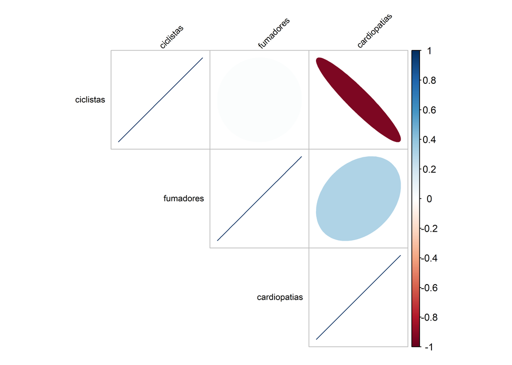

```r
plot_correlate(cardio, -ID_ciudad)
```

En los argumentos de las funciones omitimos la variable ID_ciudad y dejamos todas las otras. Encontramos de forma analítica y gráfica que existe una alta correlación inversa entre cardiopatías y ciclistas (-0,93), una baja relación directa entre cardiopatías y fumadores (0,31) y una correlación inexistente entre ciclistas y fumadores (0,01).

Otra función interesante es `ggcorrmat()` del paquete **ggstatsplot** (que debemos tener instalado previamente).

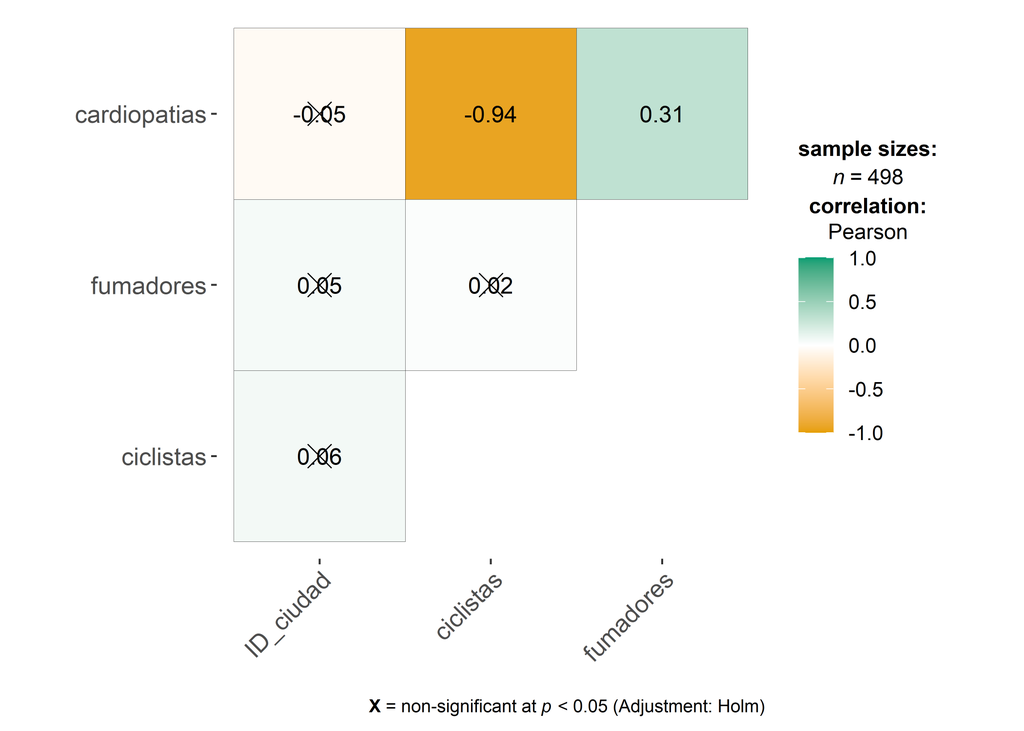

```r
library(ggstatsplot)

ggcorrmat(cardio)
```

Además del coeficiente de correlación de Pearson y los colores con sus intensidades agrega de modo directo la significación (valores tachados por una X no son significativos).

### Estrategia de construcción del modelo

A la hora de seleccionar las variables independientes que deben formar parte del modelo se pueden seguir varios métodos:

**Método jerárquico (forward)**: se basa en el criterio del investigador que introduce predictores determinados en un orden específico en relación al marco teórico. Es una estrategia forward manual, dado que se comienza con un modelo mínimo o nulo y se van incorporando variables.

**Método de entrada forzada (backward)**: es el método inverso al anterior. Se introducen todos los predictores simultáneamente y luego se van quitando los que no son significativos. Es una estrategia backward manual.

**Método paso a paso (stepwise)**: emplea criterios matemáticos para decidir qué predictores contribuyen significativamente al modelo y en qué orden se introducen.

Un índice común utilizado en lenguaje R es Akaike Information Criterion (AIC) que ajusta mediante *máxima verosimilitud* (función `AIC()`). El algoritmo AIC busca el modelo equilibrado que describa adecuadamente la relación y tenga el mínimo AIC (es decir, cuanto más pequeño es el índice mejor es el modelo).

Dentro de este método automático se diferencian tres estrategias:

**Dirección forward**: El modelo inicial no contiene ningún predictor, solo el intercepto ($\beta_0$). A partir de este se generan todos los posibles modelos introduciendo una sola variable de entre las disponibles. Aquella variable que mejore en mayor medida el modelo se selecciona. A continuación se intenta incrementar el modelo probando a introducir una a una las variables restantes. Si introduciendo alguna de ellas mejora, también se selecciona. En el caso de que varias lo hagan, se selecciona la que incremente en mayor medida la capacidad del modelo. Este proceso se repite hasta llegar al punto en el que ninguna de las variables que quedan por incorporar mejore el modelo.

**Dirección backward**: El modelo se inicia “saturado”, es decir con todas las variables disponibles incluidas como predictores. Se prueba a eliminar una a una cada variable, si se mejora el modelo, queda excluida. Este método permite evaluar cada variable en presencia de las otras.

**Doble o mixto**: Se trata de una combinación de la selección forward y backward. Se inicia igual que el forward pero tras cada nueva incorporación se realiza un test de extracción de predictores no útiles como en el backward. Presenta la ventaja de que si a medida que se añaden predictores, alguno de los ya presentes deja de contribuir al modelo, se elimina.

La función `step()` en R base permite encontrar el mejor modelo basado en AIC utilizando cualquiera de las 3 variantes automáticas del método paso a paso.

Siempre es oportuno aclarar que estos últimos métodos se basan en cálculos matemático/estadísticos que no tienen en cuenta criterios conceptuales epidemiológicos que surjan del marco teórico, por lo que exigen un control especial del analista.

Como siempre el lenguaje R ofrece una variedad de funciones (algunas base y otras provenientes de paquetes adicionales) para abordar y facilitar la tarea de seleccionar el mejor modelo de regresión (aquel que mejor explique la relación entre variables y que a la vez sea el más simple - principio de parsimonia).

El índice de bondad de ajuste utilizado para compararlos, además del AIC, es el $R^2 \; ajustado$.

Como consecuencia de tener solo dos variables independientes posibles y a modo didáctico, vamos a crear tres objetos de regresión, dos de ellos regresiones lineales simples y uno de regresión lineal múltiple:

```r
mod_simple1 <- lm(cardiopatias ~ ciclistas, data = cardio)

mod_simple2 <- lm(cardiopatias ~ fumadores, data = cardio)

mod_multiple <- lm(cardiopatias ~ ciclistas + fumadores, data = cardio)
```

Mediante `summary()` observamos sus resultados:

```r
summary(mod_simple1)
```

```
Call:
lm(formula = cardiopatias ~ ciclistas, data = cardio)

Residuals:
   Min     1Q Median     3Q    Max
-4.028 -1.206 -0.004  1.151  3.643

Coefficients:
             Estimate Std. Error t value Pr(>|t|)
(Intercept) 17.697884   0.146780  120.57   <2e-16 ***
ciclistas   -0.199091   0.003378  -58.94   <2e-16 ***
---
Signif. codes:  0 '***' 0.001 '**' 0.01 '*' 0.05 '.' 0.1 ' ' 1

Residual standard error: 1.618 on 496 degrees of freedom
Multiple R-squared:  0.8751,    Adjusted R-squared:  0.8748
F-statistic:  3474 on 1 and 496 DF,  p-value: < 2.2e-16
```

```r
summary(mod_simple2)
```

```
Call:
lm(formula = cardiopatias ~ fumadores, data = cardio)

Residuals:
    Min      1Q  Median      3Q     Max
-8.7065 -3.7069  0.5007  3.6597  8.5434

Coefficients:
            Estimate Std. Error t value Pr(>|t|)
(Intercept)  7.54311    0.41251  18.286  < 2e-16 ***
fumadores    0.17048    0.02355   7.239 1.73e-12 ***
---
Signif. codes:  0 '***' 0.001 '**' 0.01 '*' 0.05 '.' 0.1 ' ' 1

Residual standard error: 4.352 on 496 degrees of freedom
Multiple R-squared:  0.09556,   Adjusted R-squared:  0.09374
F-statistic: 52.41 on 1 and 496 DF,  p-value: 1.729e-12
```

```r
summary(mod_multiple)
```

```
Call:
lm(formula = cardiopatias ~ ciclistas + fumadores, data = cardio)

Residuals:
    Min      1Q  Median      3Q     Max
-2.1789 -0.4463  0.0362  0.4422  1.9331

Coefficients:
             Estimate Std. Error t value Pr(>|t|)
(Intercept) 14.984658   0.080137  186.99   <2e-16 ***
ciclistas   -0.200133   0.001366 -146.53   <2e-16 ***
fumadores    0.178334   0.003539   50.39   <2e-16 ***
---
Signif. codes:  0 '***' 0.001 '**' 0.01 '*' 0.05 '.' 0.1 ' ' 1

Residual standard error: 0.654 on 495 degrees of freedom
Multiple R-squared:  0.9796,    Adjusted R-squared:  0.9795
F-statistic: 1.19e+04 on 2 and 495 DF,  p-value: < 2.2e-16
```

En los resúmenes observamos que todos los coeficientes de las variables involucradas son significativas y que los valores mostrados tienen forma de lista, es decir no son tablas “ordenadas” por lo que muchas veces, sobretodo cuando trabajamos con numerosas variables, se hace difícil la comparación de resultados.

### Comparación de modelos

Algunas funciones vienen a aportar una solución sencilla para la comparación de modelos. Es el caso de `compare_models()` del paquete **paremeters** y `compare_performance()` del paquete **performance**.

```r
library(parameters)

compare_models(mod_simple1, mod_simple2, mod_multiple)
```

```
Parameter    |          mod_simple1 |       mod_simple2 |         mod_multiple
------------------------------------------------------------------------------
(Intercept)  | 17.70 (17.41, 17.99) | 7.54 (6.73, 8.35) | 14.98 (14.83, 15.14)
ciclistas    | -0.20 (-0.21, -0.19) |                   | -0.20 (-0.20, -0.20)
fumadores    |                      | 0.17 (0.12, 0.22) |  0.18 ( 0.17,  0.19)
------------------------------------------------------------------------------
Observations |                  498 |               498 |                  498
```

Se muestran para cada modelo, los coeficientes y sus IC.

```r
library(performance)

compare_performance(mod_simple1, mod_simple2, mod_multiple,
                    metrics = "common")
```

```
# Comparison of Model Performance Indices

Name         | Model |      AIC |      BIC |    R2 | R2 (adj.) |  RMSE
----------------------------------------------------------------------
mod_simple1  |    lm | 1896.237 | 1908.869 | 0.875 |     0.875 | 1.614
mod_simple2  |    lm | 2882.085 | 2894.717 | 0.096 |     0.094 | 4.344
mod_multiple |    lm |  995.353 | 1012.196 | 0.980 |     0.980 | 0.652
```

Las métricas comunes extraídas de los objetos de regresión, presentadas en una tabla, son:

- **AIC**: Criterio de información de Akaike
- **BIC**: Criterio de información bayesiano
- **R2**: Coeficiente de determinación $R^2$
- **R2 (adj.)**: Coeficiente de determinación ajustado
- **RMSE**: Error cuadrático medio

En este ejemplo, vemos que el modelo simple de ciclistas es mucho mejor que el modelo simple de fumadores, pero el modelo múltiple que incluye ambas variables tiene aún mejores índices (menor AIC y RMSE y mayor $R^2$ ajustado.

### Colinealidad

Hay varias formas de intuir si hay colinealidad, es decir relación lineal entre nuestras variables independientes.

La primera es analizar el coeficiente de correlación; si tenemos variables altamente relacionadas es muy probable que el modelo pueda tener colinealidad entre esas variables independientes.

Otro de los síntomas se produce cuando nuestro modelo tiene un alto coeficiente de correlación ($R^2$) y muchas variables no son significativas. En estos casos también es muy probable la existencia de colinealidad.

Cuando hemos intuido que tenemos multicolinealidad y queremos comprobar, el paquete **car** nos ofrece una función que implementa el método VIF (variance inflation factor).

Este factor cuantifica la intensidad de la multicolinealidad en un análisis de regresión normal de mínimos cuadrados y se utiliza así:

```r
library(car)

vif(mod_multiple)
```

```
ciclistas fumadores
 1.000229  1.000229
```

Los resultados del ejemplo muestra VIF bajos, cerca del 1 que es el valor más bajo del índice (no hay colinealidad).

El umbral de detección parte de valores 4 o 5, donde debería llamarnos la atención. Un valor 10 o superior indicaría que el modelo de regresión lineal presenta un grado de multicolinealidad preocupante.

### Diagnóstico del modelo (análisis de residuos)

El diagnóstico final del modelo elegido lo debemos realizar con sus residuos.

La forma gráfica habitual es “plotear” el objeto de regresión.

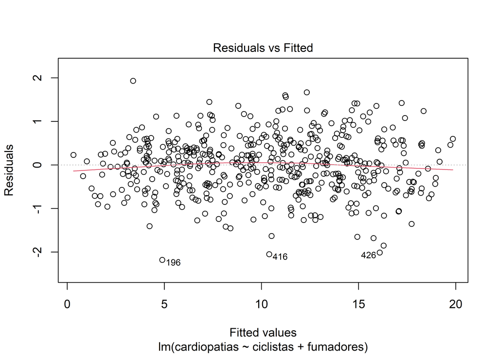

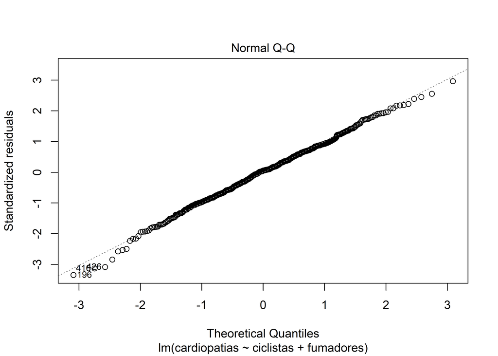

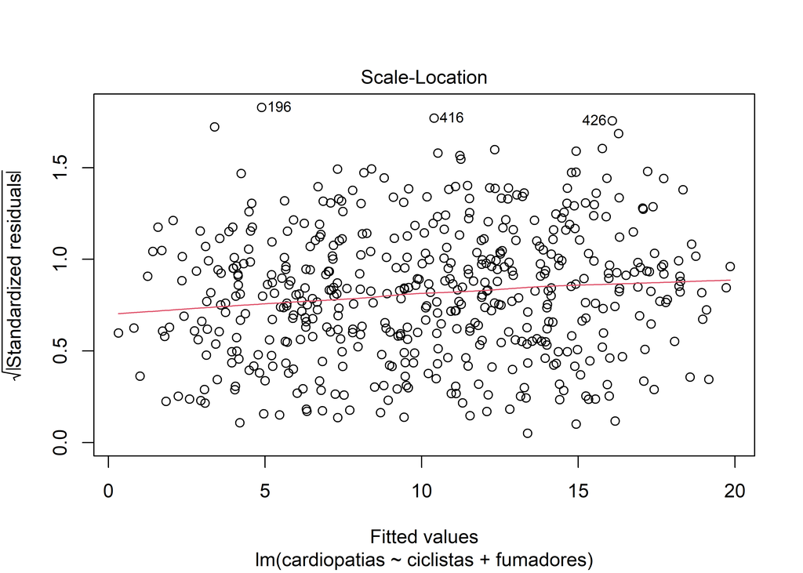

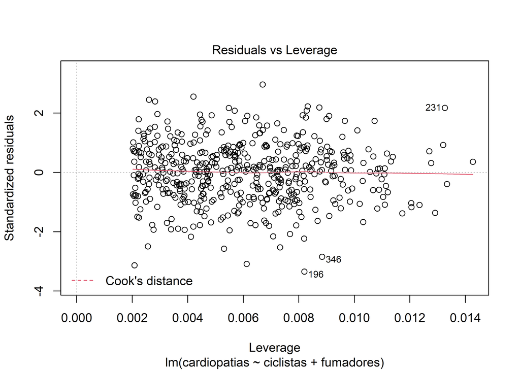

```r
plot(mod_multiple)
```

Por otra parte, también tenemos las funciones de análisis para los supuestos (independencia, linealidad, normalidad, homocedasticidad)

**Independencia con estadístico de Durbin-Watson**

```r
library(lmtest)

dwtest(mod_multiple)
```

```
    Durbin-Watson test

data:  mod_multiple
DW = 1.9174, p-value = 0.1773
alternative hypothesis: true autocorrelation is greater than 0
```

El valor de p es de 0,1773 por lo que no podemos rechazar la hipótesis nula de inexistencia de autocorrelación (independencia)

**Linealidad con estadístico Ramsey’s RESET**

```r
resettest(mod_multiple)
```

```
    RESET test

data:  mod_multiple
RESET = 1.4433, df1 = 2, df2 = 493, p-value = 0.2372
```

El p valor es de 0,2372 por lo que no podemos rechazar la hipótesis nula de linealidad.

**Normalidad de los residuos con test de Lilliefors**

```r
library(nortest)

lillie.test(mod_multiple$residuals)
```

```
    Lilliefors (Kolmogorov-Smirnov) normality test

data:  mod_multiple$residuals
D = 0.031511, p-value = 0.2681
```

Los resultados del test nos confirman lo visto en el grafico Q-Q, el valor p es de 0,2681 y no podemos descartar normalidad de los residuos.

**Homocedasticidad con test de Breush-Pagan**

```r
bptest(mod_multiple)
```

```
    studentized Breusch-Pagan test

data:  mod_multiple
BP = 5.7775, df = 2, p-value = 0.05564
```

Cumple con el supuesto de homocedasticidad (valor p al límite mayor a 0,05)

Finalmente presentamos un paquete interesante para validar supuestos de modelos lineales denominado **gvlma**.

Su función, de mismo nombre `gvlma()`, implementa un procedimiento global sobre vector residual estandarizado para probar los cuatro supuestos del modelo lineal.

Si el procedimiento global indica una violación de al menos uno de los supuestos, los componentes se pueden utilizar para obtener información sobre qué supuestos se han violado.

```r
library(gvlma)

gvlma(mod_multiple)
```

```
Call:
lm(formula = cardiopatias ~ ciclistas + fumadores, data = cardio)

Coefficients:
(Intercept)    ciclistas    fumadores
    14.9847      -0.2001       0.1783


ASSESSMENT OF THE LINEAR MODEL ASSUMPTIONS
USING THE GLOBAL TEST ON 4 DEGREES-OF-FREEDOM:
Level of Significance =  0.05

Call:
 gvlma(x = mod_multiple)

                    Value p-value                Decision
Global Stat        5.8125  0.2136 Assumptions acceptable.
Skewness           1.6568  0.1980 Assumptions acceptable.
Kurtosis           0.9251  0.3361 Assumptions acceptable.
Link Function      2.6348  0.1045 Assumptions acceptable.
Heteroscedasticity 0.5958  0.4402 Assumptions acceptable.
```

Todos los resultados son aceptables.

### Resumen del mejor modelo elegido

```r
summary(mod_multiple)
```

```
Call:
lm(formula = cardiopatias ~ ciclistas + fumadores, data = cardio)

Residuals:
    Min      1Q  Median      3Q     Max
-2.1789 -0.4463  0.0362  0.4422  1.9331

Coefficients:
             Estimate Std. Error t value Pr(>|t|)
(Intercept) 14.984658   0.080137  186.99   <2e-16 ***
ciclistas   -0.200133   0.001366 -146.53   <2e-16 ***
fumadores    0.178334   0.003539   50.39   <2e-16 ***
---
Signif. codes:  0 '***' 0.001 '**' 0.01 '*' 0.05 '.' 0.1 ' ' 1

Residual standard error: 0.654 on 495 degrees of freedom
Multiple R-squared:  0.9796,    Adjusted R-squared:  0.9795
F-statistic: 1.19e+04 on 2 and 495 DF,  p-value: < 2.2e-16
```

El modelo **mod_multiple** es capaz de explicar el 97,95 % de la variabilidad observada en la proporción de cardiopatías de estas ciudades. $R^2$-Adjustado: 0,9795). El test F global muestra que es significativo (p-value: < 2.2e-16).

Se satisfacen todas las condiciones para la regresión lineal.

### Funciones para modelado automático

El uso de la función `step()` se enmarca en los procedimientos automáticos y puede ser forward, backward o mixto.

La sintaxis básica de la función es:

> step(objeto, direction)

donde:

**objeto** es el modelo inicial de regresión lineal (nulo o saturado)

**direction** es la dirección que indicamos. Puede ser “forward”, “backward” o “both” (predeterminado, si no se define)

Generalmente conviene partir del modelo saturado y utilizar la dirección por defecto, donde se usan ambas direcciones.

```r
modelo_saturado <- lm(cardiopatias ~ .-ID_ciudad, data = cardio)

modelo_step <- step(modelo_saturado, direction = "both") # el argumento direction se puede omitir
```

```
Start:  AIC=-419.91
cardiopatias ~ (ID_ciudad + ciclistas + fumadores) - ID_ciudad

            Df Sum of Sq    RSS     AIC
<none>                    211.7 -419.91
- fumadores  1    1086.0 1297.7  480.97
- ciclistas  1    9183.8 9395.6 1466.82
```

Observamos que arribamos al mismo resultado con las dos variables, esperable dado la cantidad mínima de variables para la regresión múltiple.

```r
summary(modelo_step)
```

```
Call:
lm(formula = cardiopatias ~ (ID_ciudad + ciclistas + fumadores) -
    ID_ciudad, data = cardio)

Residuals:
    Min      1Q  Median      3Q     Max
-2.1789 -0.4463  0.0362  0.4422  1.9331

Coefficients:
             Estimate Std. Error t value Pr(>|t|)
(Intercept) 14.984658   0.080137  186.99   <2e-16 ***
ciclistas   -0.200133   0.001366 -146.53   <2e-16 ***
fumadores    0.178334   0.003539   50.39   <2e-16 ***
---
Signif. codes:  0 '***' 0.001 '**' 0.01 '*' 0.05 '.' 0.1 ' ' 1

Residual standard error: 0.654 on 495 degrees of freedom
Multiple R-squared:  0.9796,    Adjusted R-squared:  0.9795
F-statistic: 1.19e+04 on 2 and 495 DF,  p-value: < 2.2e-16
```

### Inclusión de variables categóricas

Si bien en este ejemplo no tenemos variables categóricas, cuando debemos introducirlas como independientes, una categoría (habitualmente denominado nivel) de la variable se considera el nivel de referencia (normalmente codificado como 0) y el resto de los niveles se comparan con él.

En el caso que el predictor categórico tenga más de dos niveles, se generan las variables `dummy` (presentadas anteriormente) para cada uno de los niveles del predictor categórico y que pueden tomar el valor de 0 o 1.

Cada vez que se emplee el modelo para predecir un valor, solamente una variable *dummy* por predictor adquiere el valor 1 (la que coincida con el valor que adquiere el predictor en ese caso) mientras que el resto se consideran 0.

El valor del coeficiente parcial de regresión $\beta_i$ de cada variable *dummy* indica la proporción promedio en el que influye dicho nivel sobre la variable dependiente $Y$ en comparación con el nivel de referencia de dicho predictor.

Las consideraciones técnicas dentro de R para que el lenguaje se encargue de construir las variables dummy automáticamente de forma interna es trabajar con **factores**.

Los tipos de datos **factor** tienen una estructura de niveles donde el primero de ellos es el de referencia. Para modificar el nivel de referencia podemos utilizar la función `relevel()` de R base.

## Bibliografía

Daniel W. Bioestadística: Base para el análisis de las ciencias de la salud. 4° Edición. Ed. Limusa Wiley, 2002.

Ballester F. y Tenías Burrillo J. M. Estudios ecológicos. Quaderns de Salut Pública i Administració de Serveis de Salut 20. Valencia: Escola Valenciana d´Estudis per a la Salut, 2003.

Epidemiología. Diseño y análisis de estudios. Mauricio Hernández Ávila. Editorial Médica Panamericana, 2007.

Escuela Nacional de Sanidad (ENS). Instituto de Salud Carlos III. Ministerio de Ciencia e Innovación. Manual Docente de la Escuela Nacional de Sanidad .Método epidemiológico. Madrid, 2009.

Triola, M. Estadística. 10° Edición. Pearson Educación. México. 2009.

Simon J. Sheather, A Modern Approach to Regression with R. Department of Statistics, College Station, TX, USA, Springer Science+Business Media, LLC, 2009

Sanford Weisberg, Applied Linear Regression. School of Statistics, University of Minnesota. John Wiley & Sons, Inc, 2005

R Core Team. R: A language and environment for statistical computing. R Foundation for Statistical Computing, Vienna, Austria, 2021. URL https://www.R-project.org/.

Choonghyun Ryu. dlookr: Tools for Data Diagnosis, Exploration, Transformation. R package version 0.4.4. 2021. https://CRAN.R-project.org/package=dlookr

Juergen Gross and Uwe Ligges. nortest: Tests for Normality. R package version 1.0-4. 2015 https://CRAN.R-project.org/package=nortest

Wickham et al. Welcome to the tidyverse. Journal of Open Source Software, 4(43), 1686, Año 2019 https://doi.org/10.21105/joss.01686

Achim Zeileis, Torsten Hothorn. Diagnostic Checking in Regression Relationships. R News 2(3), 7-10. Año 2002. URL https://CRAN.R-project.org/doc/Rnews/

Patil, I. ggstatsplot: ‘ggplot2’ Based Plots with Statistical Details., 2018 CRAN. Retrieved from https://cran.r-project.org/web/packages/ggstatsplot/index.html

John Fox and Sanford Weisberg. An {R} Companion to Applied Regression, Third Edition. Thousand Oaks CA: Sage., 2019 URL: https://socialsciences.mcmaster.ca/jfox/Books/Companion/

Edsel A. Pena and Elizabeth H. Slate. gvlma: Global Validation of Linear Models Assumptions. R package version 1.0.0.3., 2019 https://CRAN.R-project.org/package=gvlma

Lüdecke D, Ben-Shachar M, Patil I, Makowski D. “Extracting, Computing and Exploring the Parameters of Statistical Models using R.” *Journal of Open Source Software*, *5*(53), 2445., 2020 doi: 10.21105/joss.02445 (URL: https://doi.org/10.21105/joss.02445).